# Comparing MCAS criteria to other conditions

```r
library(tidyverse)
library(here)
library(vegan)
library(RColorBrewer)
library(broom)
source(here("util_functions.R"))
```

```r
df <- read_csv(here("data/compiled_all_chatgpt_diagnoses.csv"))
df
```

| file | iteration | diagnosis | criteria |
| --- | --- | --- | --- |
| diagnosis_data_230716_173935.RDS | 1 | urinary incontinence | mcas_consortium |
| diagnosis_data_230716_173935.RDS | 1 | hypotension | mcas_consortium |
| diagnosis_data_230716_173935.RDS | 1 | vomiting | mcas_consortium |
| diagnosis_data_230716_173935.RDS | 1 | abdominal cramps | mcas_consortium |
| diagnosis_data_230716_173935.RDS | 1 | angioedema | mcas_consortium |
| diagnosis_data_230716_173935.RDS | 1 | urinary tract infection | mcas_consortium |
| diagnosis_data_230716_173935.RDS | 1 | gastroenteritis | mcas_consortium |
| diagnosis_data_230716_173935.RDS | 1 | irritable bowel syndrome | mcas_consortium |
| diagnosis_data_230716_173935.RDS | 1 | anaphylaxis | mcas_consortium |
| diagnosis_data_230716_173935.RDS | 1 | adrenal insufficiency | mcas_consortium |

[output cut: 990 more lines]

## Rank abundance

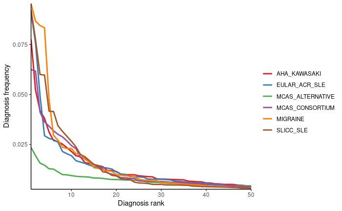

```r
# Rank abundance plot
custom_pal <- RColorBrewer::brewer.pal(7, "Set1")[-6]

df %>%
  count(criteria, diagnosis, sort = T) %>%
  group_by(criteria) %>%
  mutate(freq = n/sum(n)) %>%
  arrange(desc(freq), .by_group = T) %>%
  mutate(rank = 1:n()) %>%
  select(criteria, freq, rank) %>%
  mutate(cs = cumsum(freq)) %>%
  filter(rank <= 50) %>%
  mutate(criteria = toupper(criteria)) %>%
  ggplot(aes(x = rank, y = freq, color = factor(criteria)))+
    geom_line(size=1) +
    theme_classic()+
    scale_color_manual(values = custom_pal)+
  scale_x_continuous(expand = c(0,0))+
  scale_y_continuous(expand = c(0,0)) +
  labs(x = "Diagnosis rank", y = "Diagnosis frequency", color = "")
```

- The lower frequency of top diagnoses for the alternative MCAS criteria indicate that these criteria are less likely to result in a consistent set of possible outcomes than other diagnostic criteria.
- Similarly, there is a wider range of alternative diagnoses that could commonly and erroneously be captured by the alternative MCAS criteria.

# Diversity and similarity

## Shannon diversity

```r
# Calculate diversity values for diagnosis distributions
diagnosis_table <- table(df$criteria, df$diagnosis)
div_diag  <- vegan::diversity(diagnosis_table)
div_diag
```

```
    aha_kawasaki    eular_acr_sle mcas_alternative  mcas_consortium         migraine        slicc_sle
        4.768183         4.749758         6.295376         4.847143         4.134877         4.393290
```

- As above, alternative MCAS criteria can be associated with a wider range of alternative diagnoses

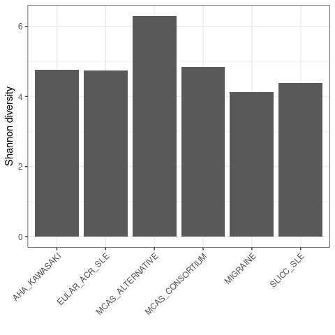

```r
# Plot diversity values
broom::tidy(div_diag) %>%
  mutate(names = toupper(names)) %>%
  ggplot(aes(x=names, y = x))+
  geom_bar(stat = "identity") +
  theme_bw() +
  labs(x = "", y = "Shannon diversity") +
  theme(axis.text.x = element_text(angle = 45, hjust = 1))
```

```r
df_entropy_difference <- as.tibble(t(combn(names(div_diag),2))) %>%
  left_join(broom::tidy(div_diag), by = c("V1" = "names")) %>%
  left_join(broom::tidy(div_diag), by = c("V2" = "names")) %>%
  mutate(entropy_difference = x.x - x.y) %>%
  unite(comp, V1, V2, sep= ".") %>%
  select(comp, entropy_difference)
df_entropy_difference
```

| comp | entropy_difference |
| --- | --- |
| aha_kawasaki.eular_acr_sle | 0.01842544 |
| aha_kawasaki.mcas_alternative | -1.52719298 |
| aha_kawasaki.mcas_consortium | -0.07896022 |
| aha_kawasaki.migraine | 0.63330633 |
| aha_kawasaki.slicc_sle | 0.37489287 |
| eular_acr_sle.mcas_alternative | -1.54561843 |
| eular_acr_sle.mcas_consortium | -0.09738567 |
| eular_acr_sle.migraine | 0.61488088 |
| eular_acr_sle.slicc_sle | 0.35646743 |
| mcas_alternative.mcas_consortium | 1.44823276 |

[output cut: 5 more lines]

### Permutation testing

```r
# Function to calculate entropy for different criteria and find
# difference between entropy values between all unique pairs
pairwise_div_difference <- function(df){
  df_div <- enframe(vegan::diversity(table(df$criteria, df$diagnosis)))
  df_diff <- data.frame(t(combn(unique(sort(df$criteria)),2))) %>%
    left_join(df_div, by = c("X1"="name")) %>%
    left_join(df_div, by = c("X2"="name")) %>%
    unite("pair", X1, X2, sep = ".") %>%
    mutate(entropy_difference = value.x - value.y) %>%
    select(-contains("value"))
  deframe(df_diff)
}

# pairwise_div_difference(df)
enframe(pairwise_div_difference(df), name = "pair", value = "entropy_difference")
```

| pair | entropy_difference |
| --- | --- |
| aha_kawasaki.eular_acr_sle | 0.01842544 |
| aha_kawasaki.mcas_alternative | -1.52719298 |
| aha_kawasaki.mcas_consortium | -0.07896022 |
| aha_kawasaki.migraine | 0.63330633 |
| aha_kawasaki.slicc_sle | 0.37489287 |
| eular_acr_sle.mcas_alternative | -1.54561843 |
| eular_acr_sle.mcas_consortium | -0.09738567 |
| eular_acr_sle.migraine | 0.61488088 |
| eular_acr_sle.slicc_sle | 0.35646743 |
| mcas_alternative.mcas_consortium | 1.44823276 |

[output cut: 5 more lines]

```r
# Randomize diagnoses
null_pairwise_div_permute <- function(resample_scope = "all"){
  # Resample diagnoses across all groups
  if (resample_scope == "all"){
    out <- df %>%
      mutate(diagnosis = sample(diagnosis, replace = F)) %>%
      pairwise_div_difference()
    return(out)
  }

  # Resample diagnosis only for a given pair of criteria
  if (resample_scope == "pair"){
    out <- as.data.frame(t(combn(unique(sort(df$criteria)),2))) %>%
      mutate(data = map2(V1, V2, function(v1,v2){
        df %>%
          ungroup() %>%
          filter(criteria == v1 | criteria == v2) %>%
          mutate(diagnosis = sample(diagnosis, replace = F))})) %>%
      select(-contains("V")) %>%
      unnest(data) %>%
      pairwise_div_difference()
    return(out)
  }
}

null_pairwise_div_permute(resample_scope = "all")
```

```
      aha_kawasaki.eular_acr_sle    aha_kawasaki.mcas_alternative     aha_kawasaki.mcas_consortium            aha_kawasaki.migraine
                    0.0174235937                     0.0254187082                     0.0197090684                     0.0260021148
          aha_kawasaki.slicc_sle   eular_acr_sle.mcas_alternative    eular_acr_sle.mcas_consortium           eular_acr_sle.migraine
                    0.0244226792                     0.0079951145                     0.0022854746                     0.0085785211
         eular_acr_sle.slicc_sle mcas_alternative.mcas_consortium        mcas_alternative.migraine       mcas_alternative.slicc_sle
                    0.0069990855                    -0.0057096398                     0.0005834066                    -0.0009960290
        mcas_consortium.migraine        mcas_consortium.slicc_sle               migraine.slicc_sle
                    0.0062930465                     0.0047136108                    -0.0015794356
```

```r
null_pairwise_div_permute(resample_scope = "pair")
```

```
      aha_kawasaki.eular_acr_sle    aha_kawasaki.mcas_alternative     aha_kawasaki.mcas_consortium            aha_kawasaki.migraine
                     0.075557545                     -0.537333428                     -0.085198685                      0.183454635
          aha_kawasaki.slicc_sle   eular_acr_sle.mcas_alternative    eular_acr_sle.mcas_consortium           eular_acr_sle.migraine
                     0.188646511                     -0.612890973                     -0.160756230                      0.107897091
         eular_acr_sle.slicc_sle mcas_alternative.mcas_consortium        mcas_alternative.migraine       mcas_alternative.slicc_sle
                     0.113088966                      0.452134743                      0.720788063                      0.725979939
        mcas_consortium.migraine        mcas_consortium.slicc_sle               migraine.slicc_sle
                     0.268653320                      0.273845196                      0.005191876
```

```r
# set.seed(1234)
# df_permute_null_div_difference_pair <- as.data.frame(t(replicate(5000, null_pairwise_div_permute(resample_scope = "pair")))) %>%
#   pivot_longer(everything(), names_to = "comp", values_to = "entropy")
# write_csv(df_permute_null_div_difference_pair, here("data/null_permute_diversity_comparison.csv"))


df_permute_null_div_difference_pair <- read_csv(here("data/null_permute_diversity_comparison.csv"))
df_permute_null_div_difference_pair
```

| comp | entropy |
| --- | --- |
| aha_kawasaki.eular_acr_sle | 0.086329863 |
| aha_kawasaki.mcas_alternative | -0.528324422 |
| aha_kawasaki.mcas_consortium | -0.079699578 |
| aha_kawasaki.migraine | 0.186586768 |
| aha_kawasaki.slicc_sle | 0.195164442 |
| eular_acr_sle.mcas_alternative | -0.614654286 |
| eular_acr_sle.mcas_consortium | -0.166029441 |
| eular_acr_sle.migraine | 0.100256905 |
| eular_acr_sle.slicc_sle | 0.108834579 |
| mcas_alternative.mcas_consortium | 0.448624845 |

[output cut: 990 more lines]

```r
df_entropy_diff_pvales <- df_permute_null_div_difference_pair %>%
  group_by(comp) %>%
  nest() %>%
  mutate(ecdf_entropy_diff = map(data, ~ecdf(abs(.$entropy)))) %>%
  mutate(null_mean = map_dbl(data, ~mean(abs(.$entropy)))) %>%
  left_join(df_entropy_difference) %>%
  mutate(entropy_difference = abs(entropy_difference)) %>%
  mutate(p_value = map2_dbl(ecdf_entropy_diff, entropy_difference, function(e,m){1-e(abs(m))})) %>%
  select(comp, null_mean, entropy_difference, contains("p_value"))
df_entropy_diff_pvales
```

| comp | null_mean | entropy_difference | p_value |
| --- | --- | --- | --- |
| aha_kawasaki.eular_acr_sle | 0.07587200 | 0.01842544 | 1.0000 |
| aha_kawasaki.mcas_alternative | 0.53401268 | 1.52719298 | 0.0000 |
| aha_kawasaki.mcas_consortium | 0.08624552 | 0.07896022 | 0.8778 |
| aha_kawasaki.migraine | 0.17402534 | 0.63330633 | 0.0000 |
| aha_kawasaki.slicc_sle | 0.19170610 | 0.37489287 | 0.0000 |
| eular_acr_sle.mcas_alternative | 0.60988468 | 1.54561843 | 0.0000 |
| eular_acr_sle.mcas_consortium | 0.16211752 | 0.09738567 | 1.0000 |
| eular_acr_sle.migraine | 0.09815334 | 0.61488088 | 0.0000 |
| eular_acr_sle.slicc_sle | 0.11583411 | 0.35646743 | 0.0000 |
| mcas_alternative.mcas_consortium | 0.44776717 | 1.44823276 | 0.0000 |

[output cut: 5 more lines]

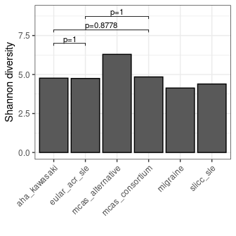

```r
broom::tidy(div_diag) %>%
  ggplot(aes(x=names, y = x))+
  geom_bar(stat = "identity", color = "black") +
  ggpubr::stat_pvalue_manual(
    df_entropy_diff_pvales %>%
      separate(comp, into = c("group1", "group2"), sep = "\\.") %>%
      filter(p_value > 0.05),
    label = "p={p_value}", y.position = 7, step.increase = 0.3, tip.length = 0.05, label.size = 3) +
  theme_bw() +
  ylim(0,9)+
  labs(x = "", y = "Shannon diversity") +
  theme(axis.text.x = element_text(angle = 45, hjust = 1))
```

- All comparisons other than those shown are significant. The increased diversity of alternative MCAS criteria associated diagnoses is significant relative to all other.

### Bootstrap CIs

```r
df_entropy_bootstrap <- df %>%
  count(criteria, diagnosis, sort = T) %>%
  group_by(criteria) %>%
  nest() %>%
  mutate(boot = map(data, function(x){
    x <- deframe(x)
    x <- entropart::EntropyCI(entropart::Shannon, Simulations=5000, Ns = x, q=1, Correction = "None")
    x
  })) %>%
  # mutate(shannon = map_dbl(data, ~vegan::diversity(deframe(.)))) %>% # Calculate shannon with vegan
  mutate(shannon = map_dbl(data, ~log(entropart::Diversity(deframe(.), q=1, Correction="None")))) %>% # Calculate shannon with entropart
  mutate(boot = map(boot, ~quantile(., c(0.025,0.975)))) %>%
  unnest_wider(boot)
df_entropy_bootstrap
```

| criteria | data | 2.5% | 97.5% | shannon |
| --- | --- | --- | --- | --- |
| migraine |  | 4.107564 | 4.161187 | 4.134877 |
| slicc_sle |  | 4.364753 | 4.421729 | 4.393290 |
| eular_acr_sle |  | 4.722749 | 4.777143 | 4.749758 |
| aha_kawasaki |  | 4.743703 | 4.793277 | 4.768183 |
| mcas_consortium |  | 4.820539 | 4.874115 | 4.847143 |
| mcas_alternative |  | 6.269044 | 6.322243 | 6.295376 |

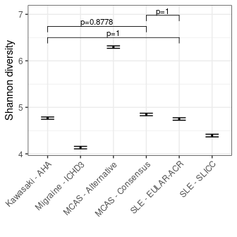

```r
criteria_order <- c("aha_kawasaki", "migraine", "mcas_alternative",
                    "mcas_consortium", "eular_acr_sle", "slicc_sle")

criteria_names <- c(
  "mcas_consortium" = "MCAS - Consensus",
  "mcas_alternative" = "MCAS - Alternative",
  "eular_acr_sle" = "SLE - EULAR-ACR",
  "slicc_sle" = "SLE - SLICC",
  "aha_kawasaki" = "Kawasaki - AHA",
  "migraine" = "Migraine - ICHD3")

df_entropy_bootstrap %>%
  mutate(criteria = factor(criteria, levels = criteria_order)) %>%
  mutate(criteria = fct_recode(criteria, !!!setNames(names(criteria_names), criteria_names))) %>%
  ggplot(aes(x = criteria, y = shannon))+
  geom_point(size = 0.5)+
  geom_errorbar(aes(ymin = `2.5%`, ymax = `97.5%`), width = 0.4)+
  ggpubr::stat_pvalue_manual(
    df_entropy_diff_pvales %>%
      separate(comp, into = c("group1", "group2"), sep = "\\.") %>%
      mutate_at(vars(contains("group")), ~factor(., levels = criteria_order)) %>%
      mutate_at(vars(contains("group")), ~fct_recode(., !!!setNames(names(criteria_names), criteria_names))) %>%
      filter(p_value > 0.05),
    label = "p={p_value}", y.position = 6.5, step.increase = 0.1, tip.length = 0.05, label.size = 3) +
  geom_violin()+
  theme_bw() +
  ylim(c(NA, 7.05))+
  theme(axis.text.x = element_text(angle = 45, hjust = 1)) +
  labs(x = "", y = "Shannon diversity")
```

### Hutcheson T-test

```r
mcas_hutch <- df %>%
  count(criteria, diagnosis) %>%
  pivot_wider(names_from = "criteria", values_from = "n", values_fill = 0) %>%
  column_to_rownames("diagnosis") %>%
  ecolTest::multiple_Hutcheson_t_test()
mcas_hutch
```

```
$p.values
                         aha_kawasaki H = 4.77 eular_acr_sle H = 4.75 mcas_alternative H = 6.3 mcas_consortium H = 4.85 migraine H = 4.13
aha_kawasaki H = 4.77                       NA                0.14727                        0                        0                 0
eular_acr_sle H = 4.75                 0.14727                     NA                        0                        0                 0
mcas_alternative H = 6.3               0.00000                0.00000                       NA                        0                 0
mcas_consortium H = 4.85               0.00000                0.00000                        0                       NA                 0
migraine H = 4.13                      0.00000                0.00000                        0                        0                NA
slicc_sle H = 4.39                     0.00000                0.00000                        0                        0                 0
                         slicc_sle H = 4.39
aha_kawasaki H = 4.77                     0
eular_acr_sle H = 4.75                    0
mcas_alternative H = 6.3                  0
mcas_consortium H = 4.85                  0
migraine H = 4.13                         0
slicc_sle H = 4.39                       NA
```

```r
df_hutch <- mcas_hutch$p.values %>%
  as.dist() %>%
  broom::tidy() %>%
  rename(group1 = item1, group2 = item2, p_value = distance) %>%
  mutate_all(~sub(" H.*","",.)) %>%
  mutate_at(vars(contains("group")), ~factor(., levels = criteria_order)) %>%
  mutate_at(vars(contains("group")), ~fct_recode(., !!!setNames(names(criteria_names), criteria_names))) %>%
  filter(p_value >= 0.05)
df_hutch
```

| group1 | group2 | p_value |
| --- | --- | --- |
| Kawasaki - AHA | SLE - EULAR-ACR | 0.14727 |

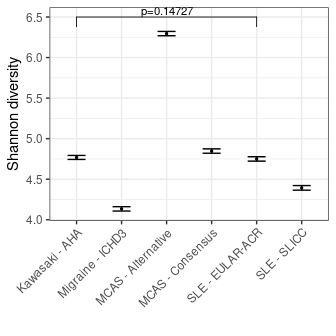

```r
df_entropy_bootstrap %>%
  mutate(criteria = factor(criteria, levels = criteria_order)) %>%
  mutate(criteria = fct_recode(criteria, !!!setNames(names(criteria_names), criteria_names))) %>%
  ggplot(aes(x = criteria, y = shannon))+
  geom_point(size = 0.5)+
  geom_errorbar(aes(ymin = `2.5%`, ymax = `97.5%`), width = 0.4)+
  ggpubr::stat_pvalue_manual(
    df_hutch, label = "p={p_value}", y.position = 6.5, step.increase = 0., tip.length = 0.05, label.size = 3) +
  geom_violin()+
  theme_bw() +
  theme(axis.text.x = element_text(angle = 45, hjust = 1)) +
  labs(x = "", y = "Shannon diversity")
```

### Asymptotic CIs for diversity difference

```r
set.seed(1234)
df_boot_CI_diff <- df %>%
  count(criteria, diagnosis) %>%
  pivot_wider(names_from = "diagnosis", values_from = "n", values_fill = 0) %>%
  column_to_rownames("criteria") %>%
  simboot::sbdiv(
    X = .,
    f = rownames(.),
    theta = "Shannon",
    type = "Tukey",
    R = 5000,
    method = "asht"
  )

as.data.frame(df_boot_CI_diff$conf.int)  %>%
  mutate(sig = ifelse(lower <=0 & upper >= 0, "ns", "*"))
```

|  | estimate | lower | upper | sig |
| --- | --- | --- | --- | --- |
| eular_acr_sle - aha_kawasaki | -0.01415756 | -0.06422993 | 0.03591481 | ns |
| mcas_alternative - aha_kawasaki | 1.57103721 | 1.52351347 | 1.61856096 | * |
| mcas_consortium - aha_kawasaki | 0.08343150 | 0.03415633 | 0.13270668 | * |
| migraine - aha_kawasaki | -0.63852269 | -0.68819794 | -0.58884745 | * |
| slicc_sle - aha_kawasaki | -0.37177168 | -0.42280437 | -0.32073900 | * |
| mcas_alternative - eular_acr_sle | 1.58519477 | 1.53554093 | 1.63484861 | * |
| mcas_consortium - eular_acr_sle | 0.09758906 | 0.04625642 | 0.14892171 | * |
| migraine - eular_acr_sle | -0.62436513 | -0.67608193 | -0.57264833 | * |
| slicc_sle - eular_acr_sle | -0.35761412 | -0.41063612 | -0.30459212 | * |
| mcas_consortium - mcas_alternative | -1.48760571 | -1.53645552 | -1.43875590 | * |

[output cut: 5 more lines]

## Bray curtis similarity

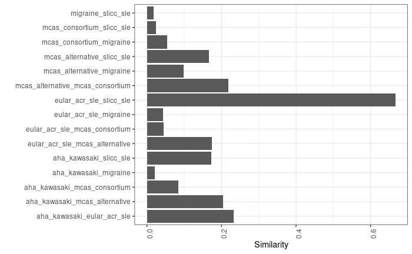

```r
# Calculate similarity
plot_similarity <- function(d_method){
  broom::tidy(1-vegan::vegdist(diagnosis_table, method = d_method)) %>%
    mutate(item = sprintf("%s_%s", item1, item2)) %>%
    ggplot(aes(x = item, y = distance)) +
    geom_bar(stat = "identity")+
    theme_bw() +
    theme(axis.text.x = element_text(angle = 90, hjust = 1)) +
    coord_flip() +
    labs(x="", y="Similarity")
}

plot_similarity("bray")
```

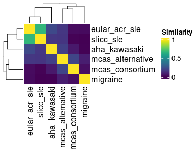

```r
# Similarity heatmap
(1-as.matrix(vegan::vegdist(diagnosis_table, method = "bray"))) %>%
  ComplexHeatmap::Heatmap(.,
                          name = "Similarity",
                          col = viridis::viridis(100))
```

- Bray-Curtis similarity measures the similarity of a given diagnostic criteria’s set of alternative diagnoses along with their frequencies.
- This demonstrates that SLE criteria results in a very similar set and frequency of diagnoses, while the diagnoses associated with two MCAS criteria are nearly as different from each other as they are from those generated by the criteria of other conditions.

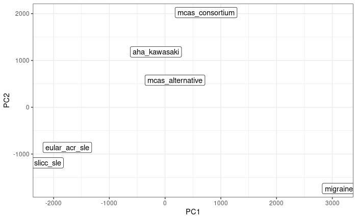

```r
# Similarity PCA
diagnosis_pca <- as.data.frame(diagnosis_table) %>%
  pivot_wider(names_from = "Var2", values_from = "Freq", values_fill = 0) %>%
  column_to_rownames("Var1") %>%
  prcomp()

as.data.frame(diagnosis_pca$x) %>%
  rownames_to_column("criteria") %>%
  ggplot(aes(x = PC1, y = PC2, label = criteria))+
  geom_label() +
  theme_bw()
```

- PCA of diagnosis frequencies is another way to group criteria by similarity.

# Precision

- Have already quantified total diversity and know that alternative MCAS criteria result in more possible output diagnoses. However, these outputs could still results in relatively consistent sets of diagnoses with only a few diagnoses varying in each set, or completely dissimilar sets in each iteration.
- A precise set of criteria would be more likely to generate a similar set of 10 diagnoses for each iteration, while a less precise set of criteria would have very different sets for each iteration
  - E.g. precise: Iteration 1 = [A,B,C,D,E,F], Iteration 2 = [A,B,C,D,X,Y]
  - E.g. not precise = Iteration 1 = [A,B,C,D,E,F], Iteration 2 = [Z,Y,X,W,V,U]
- Similarity between different iterations of diagnoses resulting from a single set of criteria can be quantified with the similarity indices like Jaccard Index
  - Chosen of Bray-Curtis, which factors in count of each diagnosis in the list, because for almost all iterations of top 10 diagnoses, no diagnosis should appear more than once.

```r
df_precision <- df %>%
  unite("sample", file, iteration, sep = "__") %>%
  group_by(criteria) %>%
  nest() %>%
  mutate(data = map(data, function(df){
    df %>%
    mutate(count = 1) %>%
    pivot_wider(names_from = "diagnosis", values_from = "count", values_fill = 0, values_fn = sum) %>%
    column_to_rownames("sample") %>%
    vegan::vegdist(method = "jaccard") %>%
    # vegan::vegdist(method = "bray") %>%
    broom::tidy()
  })) %>%
  unnest(data)
df_precision
```

| criteria | item1 | item2 | distance |
| --- | --- | --- | --- |
| mcas_consortium | diagnosis_data_230716_173935.RDS__1 | diagnosis_data_230716_173935.RDS__2 | 0.8235294 |
| mcas_consortium | diagnosis_data_230716_173935.RDS__1 | diagnosis_data_230716_173935.RDS__3 | 0.7500000 |
| mcas_consortium | diagnosis_data_230716_173935.RDS__1 | diagnosis_data_230716_173935.RDS__4 | 0.8888889 |
| mcas_consortium | diagnosis_data_230716_173935.RDS__1 | diagnosis_data_230716_173935.RDS__5 | 0.7500000 |
| mcas_consortium | diagnosis_data_230716_173935.RDS__1 | diagnosis_data_230716_173935.RDS__6 | 0.8888889 |
| mcas_consortium | diagnosis_data_230716_173935.RDS__1 | diagnosis_data_230716_173935.RDS__7 | 0.8888889 |
| mcas_consortium | diagnosis_data_230716_173935.RDS__1 | diagnosis_data_230716_173935.RDS__8 | 0.8888889 |
| mcas_consortium | diagnosis_data_230716_173935.RDS__1 | diagnosis_data_230716_173935.RDS__9 | 0.8888889 |
| mcas_consortium | diagnosis_data_230716_173935.RDS__1 | diagnosis_data_230716_173935.RDS__10 | 0.8888889 |
| mcas_consortium | diagnosis_data_230716_173935.RDS__1 | diagnosis_data_230716_173935.RDS__11 | 0.9473684 |

[output cut: 990 more lines]

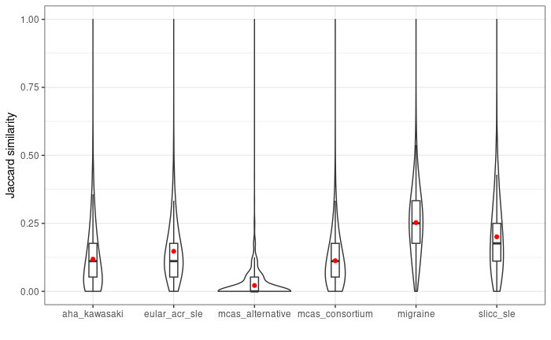

```r
df_precision %>%
  ggplot(aes(x = criteria, y = 1-distance))+
  geom_violin(adjust = 10)+
  geom_boxplot(width = 0.1, outlier.shape = NA)+
  stat_summary(fun.y = mean, geom = "point", color = "red")+
  theme_bw()+
  labs(y = "Jaccard similarity", x = "")
```

```r
df_precision_summary <- df_precision %>%
  group_by(criteria) %>%
  summarise(mean = mean(1-distance), median = median(1-distance))
df_precision_summary
```

| criteria | mean | median |
| --- | --- | --- |
| aha_kawasaki | 0.11843494 | 0.1111111 |
| eular_acr_sle | 0.14732901 | 0.1111111 |
| mcas_alternative | 0.02156956 | 0.0000000 |
| mcas_consortium | 0.11270297 | 0.1111111 |
| migraine | 0.25275812 | 0.2500000 |
| slicc_sle | 0.20060009 | 0.1764706 |

- Precision between iterations of alternative MCAS criteria is much lower than all other criteria

### Permuting within criteria

- How to answer the question of: “is the similarity between different iterations of output diagnoses more precise than random?”
- Can use permutation testing to generate a sampling distribution around the null hypothesis. i.e. that each iteration has a completely random assortment of a criteria’s total list of possible output diagnoses.
- Steps
  1. Randomize the diagnoses in each iteration
  2. Calculate Jaccard similarity between each randomized list of diagnoses
  3. Calculate the mean and median of these similarity values
  4. Repeat many times to generate null sampling distribution of mean/median Jaccard similarity
  5. Determine percentile of actual Jaccard mean/median relative to this sampling distribution and see if it satisfies alternative hypothesis
- Alternative hypothesis: Mean/median Jaccard similarity is significantly higher than random at 95% confidence (i.e. one sided permutation test)
- Median is likely a better indication of central tendency given right skewed distributions

```r
# df_permute_null_precision <- read_csv("data/null_permute_precision_slurm_231210_160913.csv") # Parallel, head(100)
df_permute_null_precision <- read_csv("data/null_permute_precision_slurm_231211_135321.csv") # Parallel, all data
# df_permute_null_precision <- read_csv("data/null_permute_precision_bray_slurm_231211_180758.csv") # Parallel, bray instead of jaccard
# df_permute_null_precision  <- read_csv("data/null_permute_precision_231208_222102") %>% # Sequential
#   rename(criteria = consensus) %>%
#   mutate(criteria = ifelse(criteria == "consensus1", "mcas_consortium", criteria),
#          criteria = ifelse(criteria == "consensus2", "mcas_alternative", criteria))
df_permute_null_precision
```

| iteration | criteria | mean | median |
| --- | --- | --- | --- |
| zbZdICxMOmJIIOfmifZxAqGUZ | aha_kawasaki | 0.07972595 | 0.05263158 |
| zbZdICxMOmJIIOfmifZxAqGUZ | eular_acr_sle | 0.09208604 | 0.11111111 |
| zbZdICxMOmJIIOfmifZxAqGUZ | mcas_alternative | 0.01942035 | 0.00000000 |
| zbZdICxMOmJIIOfmifZxAqGUZ | mcas_consortium | 0.08022961 | 0.05263158 |
| zbZdICxMOmJIIOfmifZxAqGUZ | migraine | 0.13900328 | 0.11111111 |
| zbZdICxMOmJIIOfmifZxAqGUZ | slicc_sle | 0.11885897 | 0.11111111 |
| S5q70dUl4WLyv1XABaKw0n6nM | aha_kawasaki | 0.07971955 | 0.05263158 |
| S5q70dUl4WLyv1XABaKw0n6nM | eular_acr_sle | 0.09107399 | 0.11111111 |
| S5q70dUl4WLyv1XABaKw0n6nM | mcas_alternative | 0.01940509 | 0.00000000 |
| S5q70dUl4WLyv1XABaKw0n6nM | mcas_consortium | 0.07942651 | 0.05263158 |

[output cut: 990 more lines]

```r
df_permute_mean_percentiles <- df_permute_null_precision %>%
  group_by(criteria) %>%
  summarise(data = list(quantile(mean, c(0.025, 0.5, 0.95, 0.975, 1.0)))) %>%
  unnest_wider(data) %>%
  left_join(df_precision_summary %>% select(-median), by = "criteria")
df_permute_mean_percentiles
```

| criteria | 2.5% | 50% | 95% | 97.5% | 100% | mean |
| --- | --- | --- | --- | --- | --- | --- |
| aha_kawasaki | 0.07920619 | 0.08017695 | 0.08105206 | 0.08120894 | 0.08222909 | 0.11843494 |
| eular_acr_sle | 0.08989912 | 0.09110156 | 0.09207819 | 0.09230311 | 0.09336633 | 0.14732901 |
| mcas_alternative | 0.01925327 | 0.01945651 | 0.01962414 | 0.01966101 | 0.01987448 | 0.02156956 |
| mcas_consortium | 0.07860596 | 0.07957932 | 0.08041529 | 0.08058334 | 0.08140783 | 0.11270297 |
| migraine | 0.13692808 | 0.13860747 | 0.14004122 | 0.14034648 | 0.14163661 | 0.25275812 |
| slicc_sle | 0.11704654 | 0.11854140 | 0.11977772 | 0.12002877 | 0.12148762 | 0.20060009 |

```r
df_permute_median_percentiles <- df_permute_null_precision %>%
  group_by(criteria) %>%
  summarise(data = list(quantile(median, c(0.025, 0.5, 0.95, 0.975, 1.0)))) %>%
  unnest_wider(data) %>%
  left_join(df_precision_summary %>% select(-mean), by = "criteria")
df_permute_median_percentiles
```

| criteria | 2.5% | 50% | 95% | 97.5% | 100% | median |
| --- | --- | --- | --- | --- | --- | --- |
| aha_kawasaki | 0.05263158 | 0.05263158 | 0.05263158 | 0.05263158 | 0.05263158 | 0.1111111 |
| eular_acr_sle | 0.07142857 | 0.11111111 | 0.11111111 | 0.11111111 | 0.11111111 | 0.1111111 |
| mcas_alternative | 0.00000000 | 0.00000000 | 0.00000000 | 0.00000000 | 0.00000000 | 0.0000000 |
| mcas_consortium | 0.05263158 | 0.05263158 | 0.05263158 | 0.05263158 | 0.05263158 | 0.1111111 |
| migraine | 0.11111111 | 0.11111111 | 0.11111111 | 0.11111111 | 0.11111111 | 0.2500000 |
| slicc_sle | 0.11111111 | 0.11111111 | 0.11111111 | 0.11111111 | 0.11111111 | 0.1764706 |

```r
df_precision_pvales <- df_permute_null_precision %>%
  group_by(criteria) %>%
  nest() %>%
  mutate(ecdf_mean = map(data, ~ecdf(.$mean))) %>%
  mutate(ecdf_median = map(data, ~ecdf(.$median))) %>%
  left_join(df_precision_summary) %>%
  mutate(mean_p_value = map2_dbl(ecdf_mean, mean, function(e,m){1-e(m)})) %>%
  mutate(median_p_value = map2_dbl(ecdf_median, median, function(e,m){1-e(m)})) %>%
  select(criteria, contains("p_value"))
df_precision_pvales
```

| criteria | mean_p_value | median_p_value |
| --- | --- | --- |
| aha_kawasaki | 0 | 0 |
| eular_acr_sle | 0 | 0 |
| mcas_alternative | 0 | 0 |
| mcas_consortium | 0 | 0 |
| migraine | 0 | 0 |
| slicc_sle | 0 | 0 |

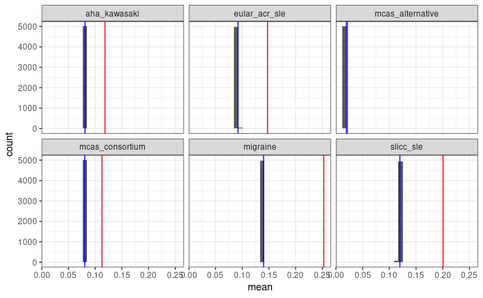

```r
df_permute_null_precision %>%
  ggplot(aes(x = mean)) +
  geom_histogram() +
  geom_vline(data = df_precision_summary, aes(xintercept = mean), color = "red")+
  geom_vline(data = df_permute_mean_percentiles, aes(xintercept = `95%`), color = "blue")+
  facet_wrap(~criteria)+
  theme_bw()
```

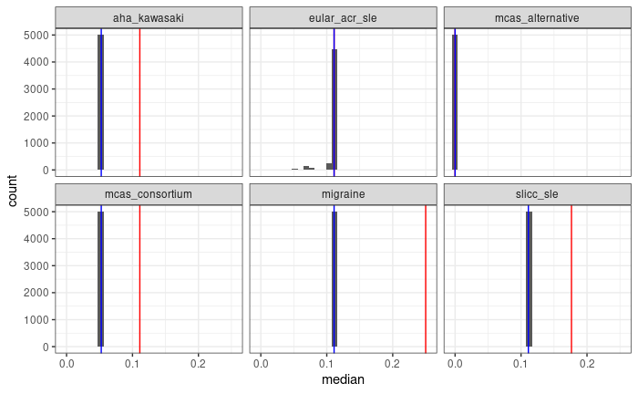

```r
df_permute_null_precision %>%
  ggplot(aes(x = median)) +
  geom_histogram() +
  geom_vline(data = df_precision_summary, aes(xintercept = median), color = "red")+
  geom_vline(data = df_permute_median_percentiles, aes(xintercept = `95%`), color = "blue")+
  facet_wrap(~criteria)+
  theme_bw()
```

- In these plots, the blue line represents the 95%tile for the permuted null sampling distribution and the red line represents the value of the actual data. If the red line is greater than the blue line it indicates that the actual value is > 95%tile of the null distribution and a p-value of < 0.05 for the 1-sided permutation test.

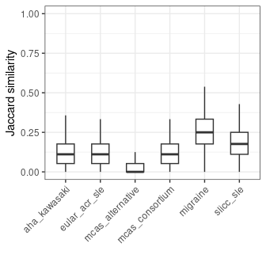

```r
df_precision %>%
  ungroup() %>%
  mutate(similarity = 1-distance) %>%
  # slice_sample(prop = 0.01) %>%
  ggplot(aes(x = criteria, y = similarity))+
  geom_boxplot(width = 0.5, outlier.shape = NA)+
  # # Add p-value asterix
  # ggpubr::stat_pvalue_manual(
  #   df_precision_pvales %>% ungroup() %>%
  #     mutate(group1 = NA, group2 = NA, p_sig = ifelse(mean_p_value < 0.05, "*","ns")),
  #   label = "p_sig",
  #   x="criteria",
  #   y.position = 0.65
  # ) +
  theme_bw()+
  theme(axis.text.x = element_text(angle = 45, hjust = 1)) +
  labs(y = "Jaccard similarity", x = "")
```

### Permuting across criteria

```r
df_precision_comparison <- as.data.frame(t(combn(sort(unique(df_precision$criteria)), 2))) %>%
  left_join(df_precision_summary, by = c("V1" = "criteria")) %>%
  left_join(df_precision_summary, by = c("V2" = "criteria")) %>%
  mutate(mean_diff = abs(mean.x - mean.y),
         median_diff = abs(median.x - median.y)) %>%
  select(V1, V2, contains("diff")) %>%
  unite(comp, V1, V2)
df_precision_comparison
```

| comp | mean_diff | median_diff |
| --- | --- | --- |
| aha_kawasaki_eular_acr_sle | 0.028894069 | 0.00000000 |
| aha_kawasaki_mcas_alternative | 0.096865379 | 0.11111111 |
| aha_kawasaki_mcas_consortium | 0.005731964 | 0.00000000 |
| aha_kawasaki_migraine | 0.134323182 | 0.13888889 |
| aha_kawasaki_slicc_sle | 0.082165152 | 0.06535948 |
| eular_acr_sle_mcas_alternative | 0.125759447 | 0.11111111 |
| eular_acr_sle_mcas_consortium | 0.034626033 | 0.00000000 |
| eular_acr_sle_migraine | 0.105429114 | 0.13888889 |
| eular_acr_sle_slicc_sle | 0.053271083 | 0.06535948 |
| mcas_alternative_mcas_consortium | 0.091133415 | 0.11111111 |

[output cut: 5 more lines]

```r
# Pairwise permutation
df_permute_null_precision_comparison <- read_csv(here("data/null_permute_precision_comparison_slurm_231211_142641.csv"))
# Simultaneously permute all groups
# df_permute_null_precision_comparison <- read_csv(here("data/null_permute_precision_comparison_slurm_231211_173937.csv"))
df_permute_null_precision_comparison
```

| iteration | V1 | V2 | mean_diff | median_diff |
| --- | --- | --- | --- | --- |
| fNsX3fbzs5iFNsTXKUq9B62Qq | aha_kawasaki | eular_acr_sle | -2.208819e-04 | 0 |
| fNsX3fbzs5iFNsTXKUq9B62Qq | aha_kawasaki | mcas_alternative | 2.288219e-04 | 0 |
| fNsX3fbzs5iFNsTXKUq9B62Qq | aha_kawasaki | mcas_consortium | 1.735338e-05 | 0 |
| fNsX3fbzs5iFNsTXKUq9B62Qq | aha_kawasaki | migraine | -5.546275e-05 | 0 |
| fNsX3fbzs5iFNsTXKUq9B62Qq | aha_kawasaki | slicc_sle | -4.541225e-05 | 0 |
| fNsX3fbzs5iFNsTXKUq9B62Qq | eular_acr_sle | mcas_alternative | 4.497037e-04 | 0 |
| fNsX3fbzs5iFNsTXKUq9B62Qq | eular_acr_sle | mcas_consortium | 2.382352e-04 | 0 |
| fNsX3fbzs5iFNsTXKUq9B62Qq | eular_acr_sle | migraine | 1.654191e-04 | 0 |
| fNsX3fbzs5iFNsTXKUq9B62Qq | eular_acr_sle | slicc_sle | 1.754696e-04 | 0 |
| fNsX3fbzs5iFNsTXKUq9B62Qq | mcas_alternative | mcas_consortium | -2.114685e-04 | 0 |

[output cut: 990 more lines]

```r
df_permute_null_precision_comparison %>%
  mutate_at(vars(contains("diff")), ~abs(.)) %>%
  unite(comp, V1, V2) %>%
  group_by(comp) %>%
  nest() %>%
  mutate(ecdf_mean_diff = map(data, ~ecdf(.$mean_diff))) %>%
  mutate(ecdf_median_diff = map(data, ~ecdf(.$median_diff))) %>%
  left_join(df_precision_comparison) %>%
  mutate(mean_p_value = map2_dbl(ecdf_mean_diff, mean_diff, function(e,m){1-e(m)})) %>%
  mutate(median_p_value = map2_dbl(ecdf_median_diff, median_diff, function(e,m){1-e(m)})) %>%
  select(comp, contains("p_value"))
```

| comp | mean_p_value | median_p_value |
| --- | --- | --- |
| aha_kawasaki_eular_acr_sle | 0 | 0 |
| aha_kawasaki_mcas_alternative | 0 | 0 |
| aha_kawasaki_mcas_consortium | 0 | 0 |
| aha_kawasaki_migraine | 0 | 0 |
| aha_kawasaki_slicc_sle | 0 | 0 |
| eular_acr_sle_mcas_alternative | 0 | 0 |
| eular_acr_sle_mcas_consortium | 0 | 0 |
| eular_acr_sle_migraine | 0 | 0 |
| eular_acr_sle_slicc_sle | 0 | 0 |
| mcas_alternative_mcas_consortium | 0 | 0 |

[output cut: 5 more lines]

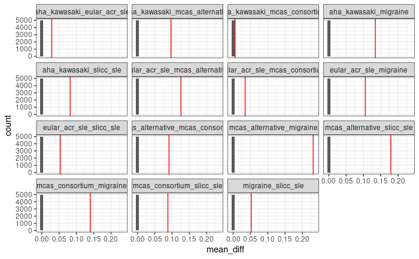

```r
df_permute_null_precision_comparison %>%
 unite(comp, V1, V2) %>%
  ggplot(aes(x = mean_diff)) +
  geom_histogram() +
  geom_vline(data = df_precision_comparison, aes(xintercept = mean_diff), color = "red")+
  # geom_vline(data = df_permute_mean_percentiles, aes(xintercept = `95%`), color = "blue")+
  facet_wrap(~comp)+
  theme_bw()
```

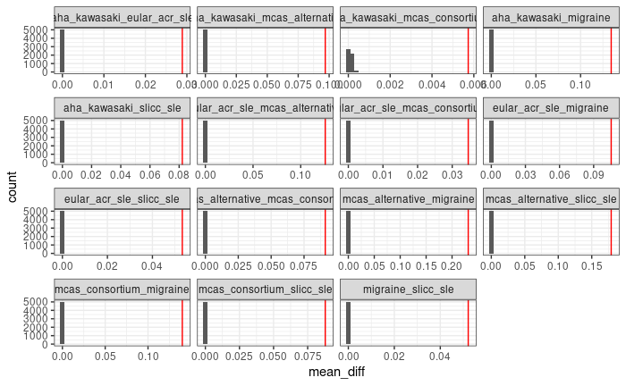

```r
df_permute_null_precision_comparison %>%
  mutate_at(vars(contains("diff")), ~abs(.)) %>%
  unite(comp, V1, V2) %>%
  ggplot(aes(x = mean_diff)) +
  geom_histogram() +
  geom_vline(data = df_precision_comparison, aes(xintercept = mean_diff), color = "red")+
  # geom_vline(data = df_permute_mean_percentiles, aes(xintercept = `95%`), color = "blue")+
  facet_wrap(~comp, scales = "free_x")+
  theme_bw()
```

# Plots

```r
points_to_inches()
```

```
Single column - 255 pts
1.5 column - 397 pts
Two column - 539 pts
```

```r
points_to_inches(255)
```

```
[1] 3.541667
```

```r
criteria_order <- c("aha_kawasaki", "migraine", "mcas_alternative",
                    "mcas_consortium", "eular_acr_sle", "slicc_sle")
```

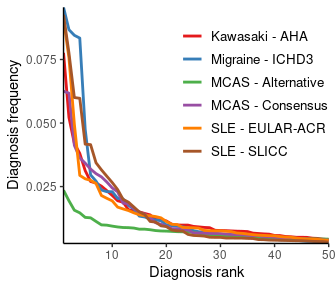

```r
custom_pal <- RColorBrewer::brewer.pal(7, "Set1")[-6]

plt_rank_abundance <- df %>%
  count(criteria, diagnosis, sort = T) %>%
  group_by(criteria) %>%
  mutate(freq = n/sum(n)) %>%
  arrange(desc(freq), .by_group = T) %>%
  mutate(rank = 1:n()) %>%
  select(criteria, freq, rank) %>%
  mutate(cs = cumsum(freq)) %>%
  filter(rank <= 50) %>%
  mutate_at(vars(contains("criteria")), ~factor(., levels = criteria_order)) %>%
  mutate_at(vars(contains("criteria")), ~fct_recode(., !!!setNames(names(criteria_names), criteria_names))) %>%
  ggplot(aes(x = rank, y = freq, color = factor(criteria)))+
    geom_line(size=1) +
    theme_classic()+
    scale_color_manual(values = custom_pal)+
    scale_x_continuous(expand = c(0,0))+
    scale_y_continuous(expand = c(0,0)) +
    labs(x = "Diagnosis rank", y = "Diagnosis frequency", color = "") +
    theme(
    legend.position = c(0.72, 0.65),
    legend.text = element_text(size = 10),
    legend.background = element_rect(fill=alpha("white",0.5)),
    legend.title = element_blank())

plt_rank_abundance
```

```r
ggsave(here("figures/3_rank_abundance_all.pdf"), plot=plt_rank_abundance, width = 3.5, height = 3)
```

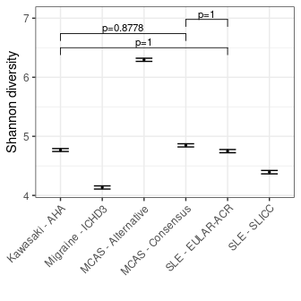

```r
criteria_order <- c("aha_kawasaki", "migraine", "mcas_alternative",
                    "mcas_consortium", "eular_acr_sle", "slicc_sle")

criteria_names <- c(
  "mcas_consortium" = "MCAS - Consensus",
  "mcas_alternative" = "MCAS - Alternative",
  "eular_acr_sle" = "SLE - EULAR-ACR",
  "slicc_sle" = "SLE - SLICC",
  "aha_kawasaki" = "Kawasaki - AHA",
  "migraine" = "Migraine - ICHD3")

plt_div <- df_entropy_bootstrap %>%
  mutate(criteria = factor(criteria, levels = criteria_order)) %>%
  mutate(criteria = fct_recode(criteria, !!!setNames(names(criteria_names), criteria_names))) %>%
  ggplot(aes(x = criteria, y = shannon))+
  geom_point(size = 0.5)+
  geom_errorbar(aes(ymin = `2.5%`, ymax = `97.5%`), width = 0.4)+
  ggpubr::stat_pvalue_manual(
    df_entropy_diff_pvales %>%
      separate(comp, into = c("group1", "group2"), sep = "\\.") %>%
      mutate_at(vars(contains("group")), ~factor(., levels = criteria_order)) %>%
      mutate_at(vars(contains("group")), ~fct_recode(., !!!setNames(names(criteria_names), criteria_names))) %>%
      filter(p_value > 0.05),
    label = "p={p_value}", y.position = 6.5, step.increase = 0.1, tip.length = 0.05, label.size = 3) +
  geom_violin()+
  theme_bw() +
  ylim(c(NA, 7.05))+
  theme(axis.text.x = element_text(angle = 45, hjust = 1)) +
  labs(x = "", y = "Shannon diversity")

plt_div
```

```r
ggsave(here("figures/3_diversity.pdf"), plot=plt_div, width = 3.5, height = 3.5)
```

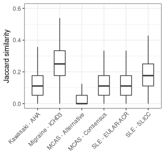

```r
plt_precision <- df_precision %>%
  ungroup() %>%
  mutate_at(vars(contains("criteria")), ~factor(., levels = criteria_order)) %>%
  mutate_at(vars(contains("criteria")), ~fct_recode(., !!!setNames(names(criteria_names), criteria_names))) %>%
  mutate(similarity = 1-distance) %>%
  ggplot(aes(x = criteria, y = similarity))+
  geom_boxplot(width = 0.5, outlier.shape = NA)+
  ylim(c(0,0.6))+
  theme_bw()+
  theme(axis.text.x = element_text(angle = 45, hjust = 1)) +
  labs(y = "Jaccard similarity", x = "")

plt_precision
```

```r
ggsave(here("figures/3_precision.pdf"), plot=plt_precision, width = 3.5, height = 3.5)
```